# r/wallstreetbets

William T. Jamieson

4/27/2021

## Why do we care?

r/wallstreetbets (r/wsb) is a subreddit frequented by retail investors. Currently it is followed by 10 million Reddit users. During late January and early February 2021, users of r/wsb realized that many large institutional firms had short positions in GameStop ($GME). The subreddit collaborated to push the stock price from $17.25 on January 4th to a high of $347.51 on January 27th. (This is called a *short squeeze*.) The firms which had shorted $GME lost an estimated $70 billion dollars, and resulting in the bankruptcy of the hedge fund Melvin Capital. Shortly there after, r/wsb users also short squeezed AMC Entertainment Holdings ($AMC).

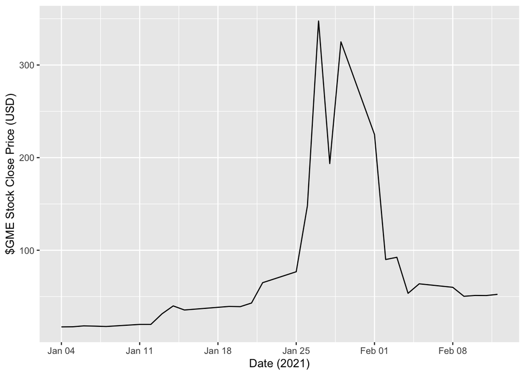

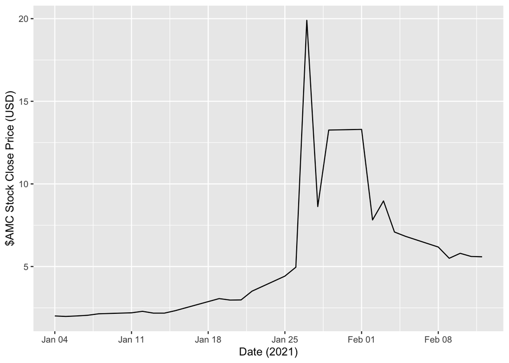

r/wsb is well known for posts which glamorize risky investing decisions which result in large gains or losses. Many retail investors jumped on the $GME and $AMC “bandwagon” as a result of reading r/wsb posts. Can natural language processing be used to analyze r/wsb comments to identify stocks whose prices are likely to increase or decrease?

## The anatomy of r/wallstreetbets

The subreddit is a message board where users can create posts which may be cross-listed with other subreddits. Users can leave comments on a post, and may reply to other users’ comments. Both posts and comments can be upvoted or downvoted, according to whether a user likes or dislikes the content of a post. A post or comment’s score is the number of upvotes minus the number of downvotes.

On a daily basis, there are hundreds of posts on r/wsb. The moderators of r/wsb create two posts every day that the stock market is open, called *Daily Discussion Thread* and *What Are Your Moves Tomorrow*. These posts routinely receive tens of thousands of comments. Given the density of information, I would like to focus on comments from these posts. As the names suggest, the Daily Discussion post receives the majority of its comments while the stock market is open, and the What Are Your Moves Tomorrow post receives the majority of its comments after the stock market has closed.

[figure not shown]

[figure not shown]

r/wallstreetbets Daily Discussions

## Data collection

There are datasets which consist of information from r/wsb posts (for example on Kaggle). Many of these datasets focus on the posts, rather than the Daily Discussion Threads, and do not contain up-to-date information. I wrote a [Python script](https://github.com/wtjamieson/wsb_eda/blob/f8cdf3df170e5849080e4d0677888f63e1bf9bce/pushshift_api) to use the PushShift API to collect the information that I am looking for. I collected the comment ID, the author, the time the comment was created, the comment text, and the comment score. A subset of the data collected on April 23th, 2021 is shown below. **(Warning: many of the comment texts contain offensive language.)**

```
## # A tibble: 10 x 5
##    id     author      created_utc         body                             score
##    <chr>  <chr>       <dttm>              <chr>                            <dbl>
##  1 gvjt3… Reknatami   2021-04-23 06:01:34 "Let's see spy hit 415 today!"       4
##  2 gvjt4… Cashmoneyt… 2021-04-23 06:01:50 "RIOT is done for"                   6
##  3 gvjt4… JiggazInPa… 2021-04-23 06:02:08 "Whoever’s reading this, I wish…   103
##  4 gvjt6… Lower_Cult… 2021-04-23 06:02:49 "GME could actually start givin…     9
##  5 gvjt6… Historical… 2021-04-23 06:02:51 "premarket looking spicy, this …     1
##  6 gvjt6… SmackEh     2021-04-23 06:02:56 "BlackBerry. It's a Canadian co…     4
##  7 gvjt6… FishnMagic… 2021-04-23 06:02:57 "More fuckn incoming"                0
##  8 gvjt7… Laurensio_  2021-04-23 06:03:08 "Yo VXX is that real or bugged"      1
##  9 gvjt7… Disastrous… 2021-04-23 06:03:20 "Someone go get the rtrds from …     5
## 10 gvjt8… e5dn10      2021-04-23 06:03:53 "Arise, arise, Redditors!\nFell…     2
```

I am using the `tidyquant` package to pull stock data from the Yahoo Finance and Alpha Vantage APIs as needed.

## Exploratory data analysis

In the analysis below, I will be using the comments from the Daily Dicussion on 4/23/2021. Let’s begin by finding the most commonly used words in the comment texts using the `tidytext` package. I am removing stop words (of, the, and, etc.) and “[removed]”, which is the body text when a comment is deleted by the author. I also performed the same analysis, but filtering by NASDAQ ticker symbols. Unfortunately, many of the ticker symbols are also standard words in the English dictionary.

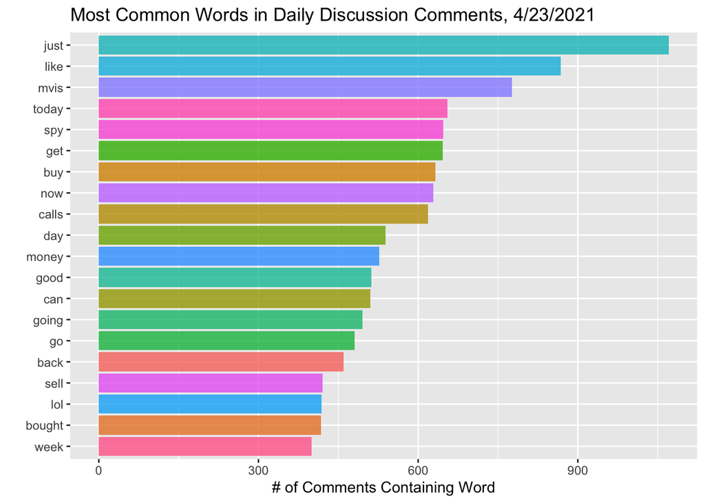

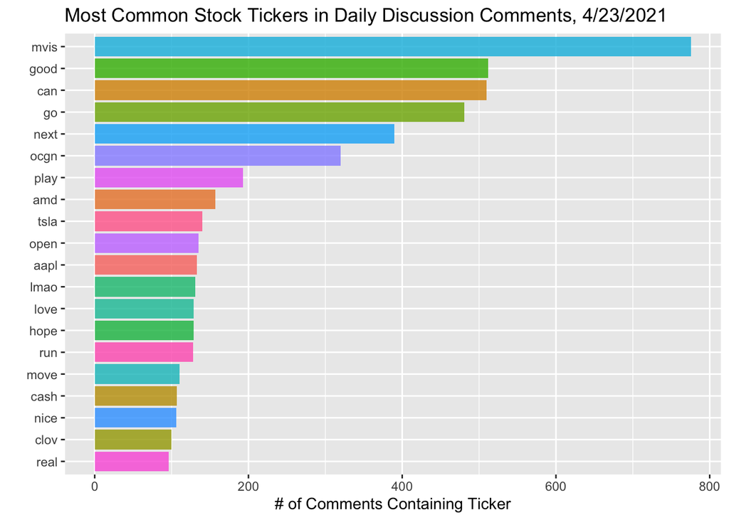

I filtered for words that appeared in more than 50 comments and calculated the mean score of (unique) comments that contained that word.

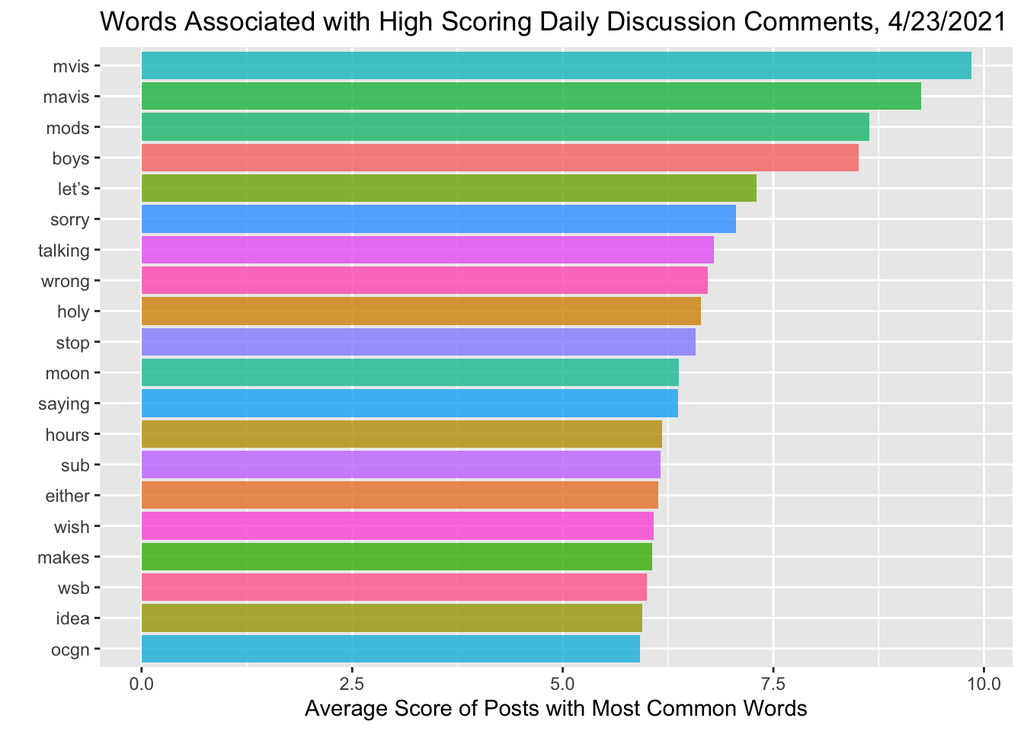

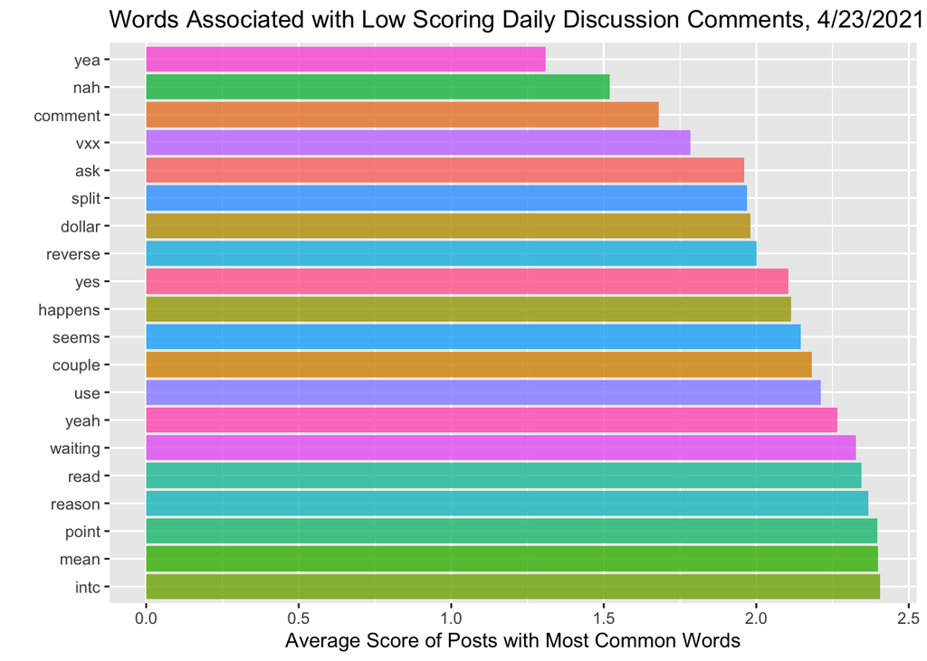

It looks like there are some stock ticker symbols ($MVIS, $SPY, $OCGN) which are being mentioned in many of the posts. In particular, many users are talking about Microvision ($MVIS), and those comments are getting many upvotes, on average. Is there anything going on with these stocks? Below, I plotted the percentage of posts per hour that involve various popular stock ticker symbols along with the stock price percentage change over each hour. The number of comments and the percentage stock price change is calculated “looking forward”- for example, all posts between 10:00AM and 10:59AM are counted as being in the 10AM hour and the percent change in stock price at 10AM is calculated as $\frac{\text{11AM Price} - \text{10AM Price}}{\text{10AM Price}}$.

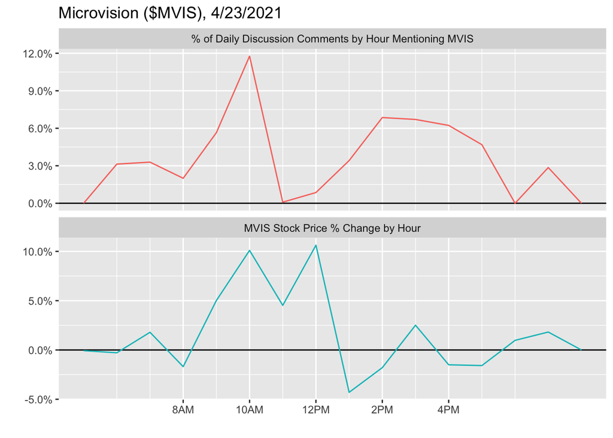

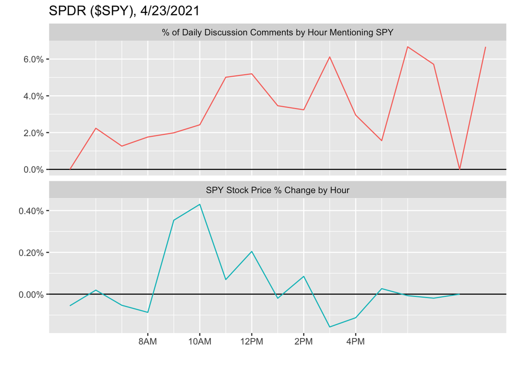

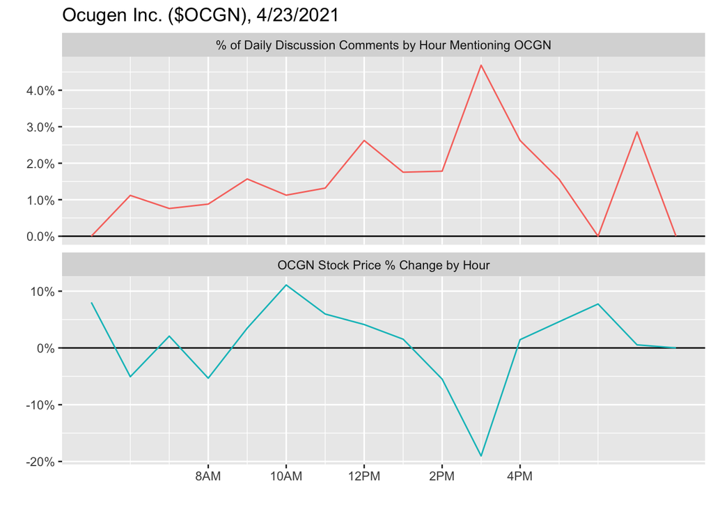

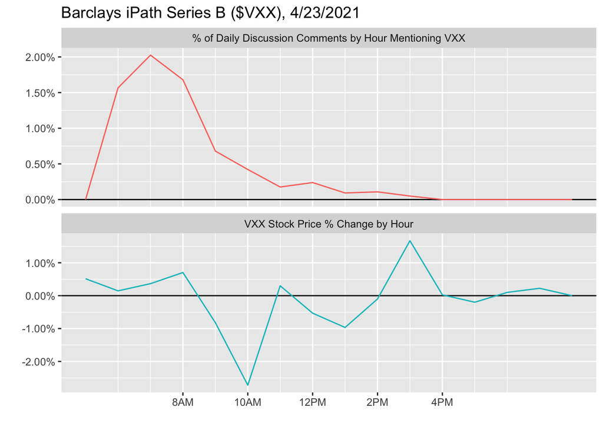

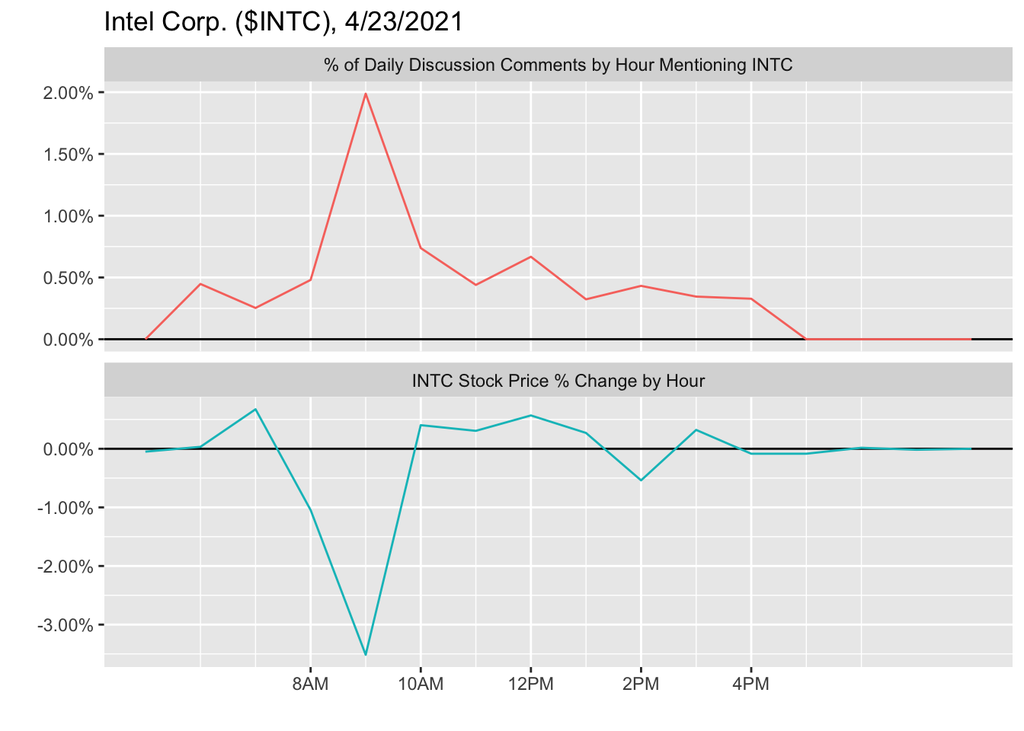

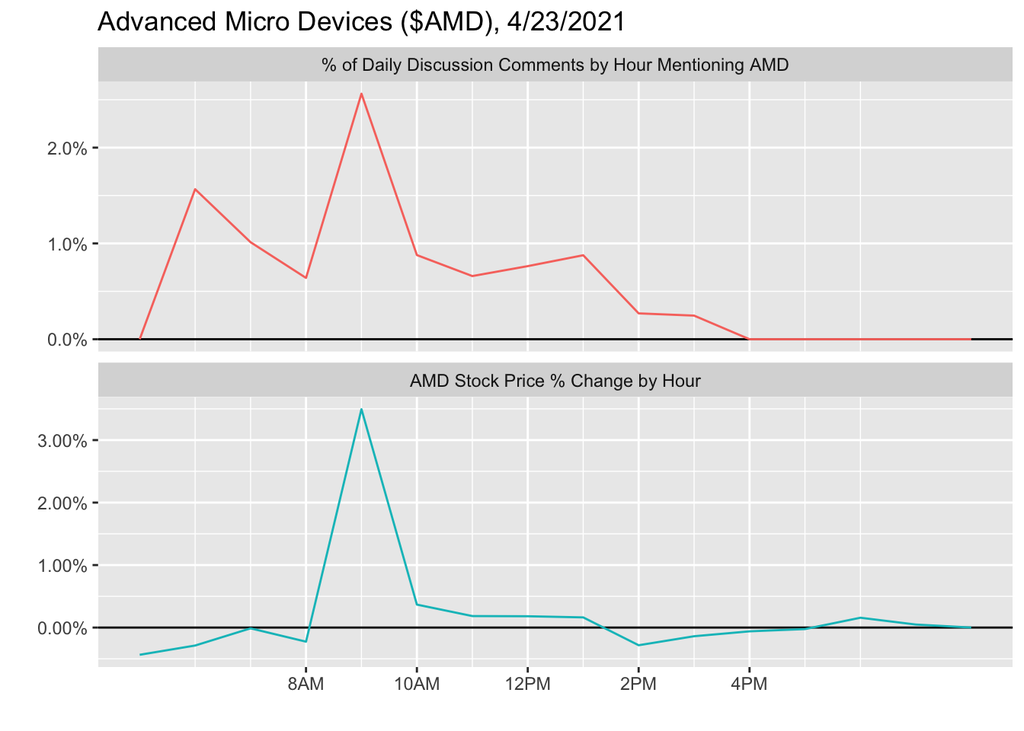

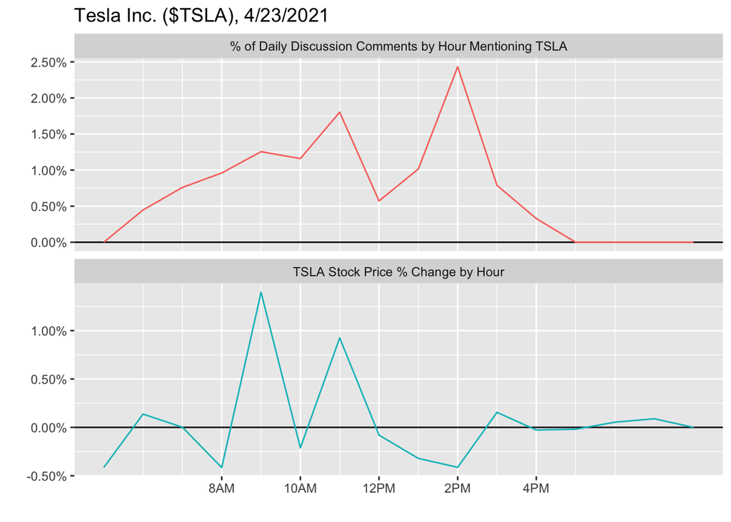

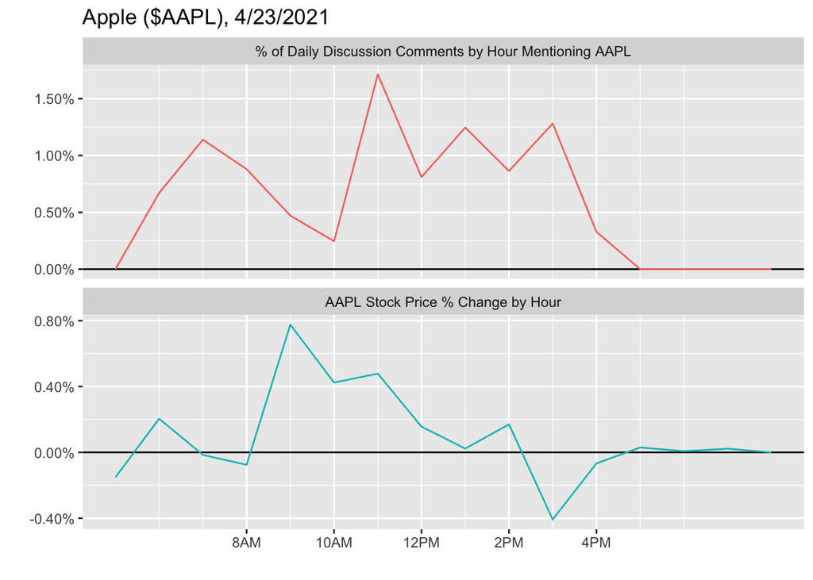

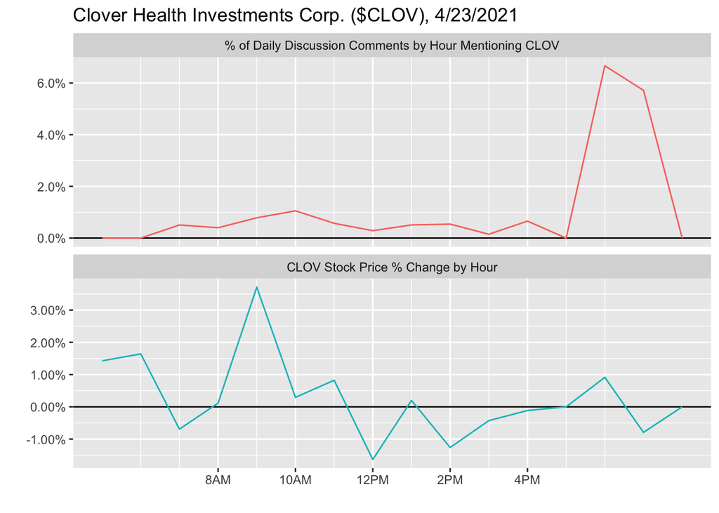

## Where can we go from here?

My end goal is to build a model which the percent change in stock price as the target variable. From the (limited) exploratory data analysis that I performed above, I believe that it might be possible to build a reasonable model on a small timescale, potentially with the addition of the What Are Your Moves Tomorrow data in order to predict changes as the stock market opens. I performed similar analysis using a Kaggle dataset over a larger timescale (days) and the resulting plots showed less promise. I am optimistic about the ability of the reddit comment scores to improve predictions, since it is a proxy both for user engagement and user sentiment. I would also like to incorporate additional variables about the stock. I think that it is reasonable to assume that r/wsb users’ ability to manipulate stock prices depends not only on the number of users discussing the stocks, but also on their ability to buy shares. Companies with a large amount of stock and/or expensive stock will require more capital from r/wsb users in order to make a noticeable impact on the stock prices. (See the $TSLA and $AAPL plots above.) Finally, I would like to explore building a custom dictionary for sentiment analysis, since the language used on r/wsb is nonstandard. For example, “moon” is a fairly neutral word in general, but is used almost exclusively as a positive word (i.e. “$GME is taking me to the moon”) on r/wsb. Similarly, derogatory terms are regularly used as greetings in positive posts, often referring to the subreddit users at large.